# Basic Statistics in R

RAdelaide 2024

Author

Affiliation

Dr Stevie Pederson

Black Ochre Data Labs  
Telethon Kids Institute

Published

July 10, 2024

# Statistics in R

## Introduction

- `R` has it’s origins as a statistical analysis language (i.e. `S`)
- Purpose of this session is NOT to teach statistical theory
  - I am a bioinformatician NOT a statistician
- Perform simple analyses in R
- Up to you to know what you’re doing
  - Or talk to your usual statisticians & collaborators

## Distributions

- `R` comes with nearly every distribution
- Standard syntax for accessing each

## Distributions

| Distribution | Density | Area Under Curve | Quantile | Random |
| --- | --- | --- | --- | --- |
| Normal | `dnorm()` | `pnorm()` | `qnorm()` | `rnorm()` |
| T | `dt()` | `pt()` | `qt()` | `rt()` |
| Uniform | `dunif()` | `punif()` | `qunif()` | `runif()` |
| Exponential | `dexp()` | `pexp()` | `qexp()` | `rexp()` |
| $\chi^2$ | `dchisq()` | `pchisq()` | `qchisq()` | `rchisq()` |
| Binomial | `dbinom()` | `pbinom()` | `qbinom()` | `rbinom()` |
| Poisson | `dpois()` | `ppois()` | `qpois()` | `rpois()` |

## Distributions

- Also Beta, $\Gamma$, Log-Normal, F, Geometric, Cauchy, Hypergeometric etc…

```r
?Distributions
```

## Distributions

**PDF**

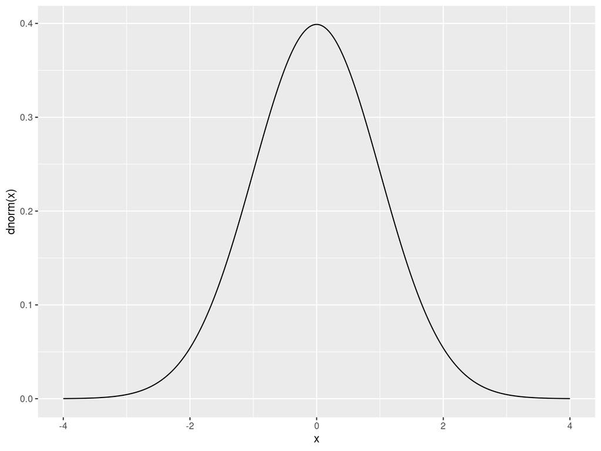

```r
## dnorm gives the classic bell-curve
tibble(
  x = seq(-4, 4, length.out = 1e3)
) %>%
  ggplot(aes(x, y = dnorm(x))) +
  geom_line()
```

**CDF**

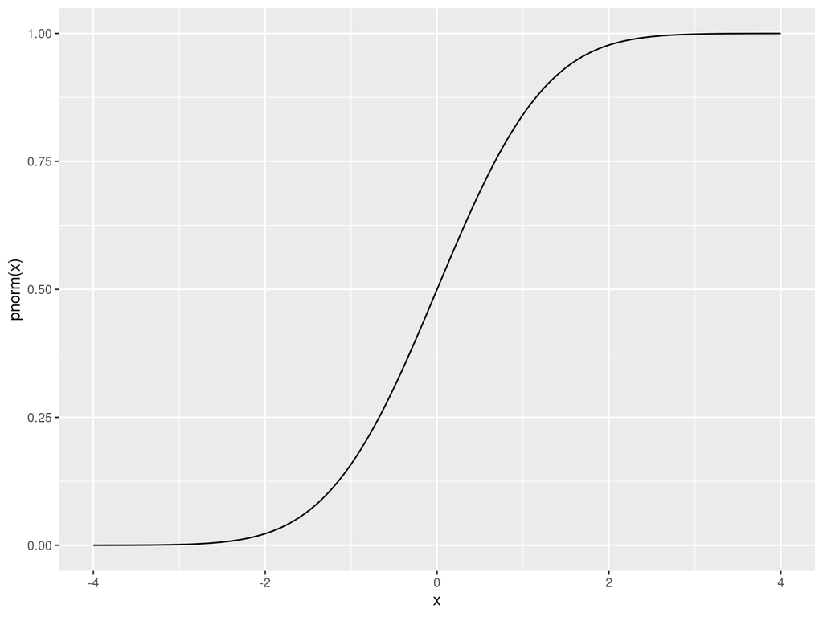

```r
## pnorm gives the area under the
## bell-curve (which sums to 1)
tibble(
  x = seq(-4, 4, length.out = 1e3)
) %>%
  ggplot(aes(x, y = pnorm(x))) +
  geom_line()
```

# Basic Tests

## Data For This Session

We’ll use the `pigs` dataset from earlier

```r
library(tidyverse)
pigs <- file.path("data", "pigs.csv") %>%
    read_csv %>%
    mutate(dose = factor(dose, levels = c("Low", "Med", "High")))
```

## Data For This Session

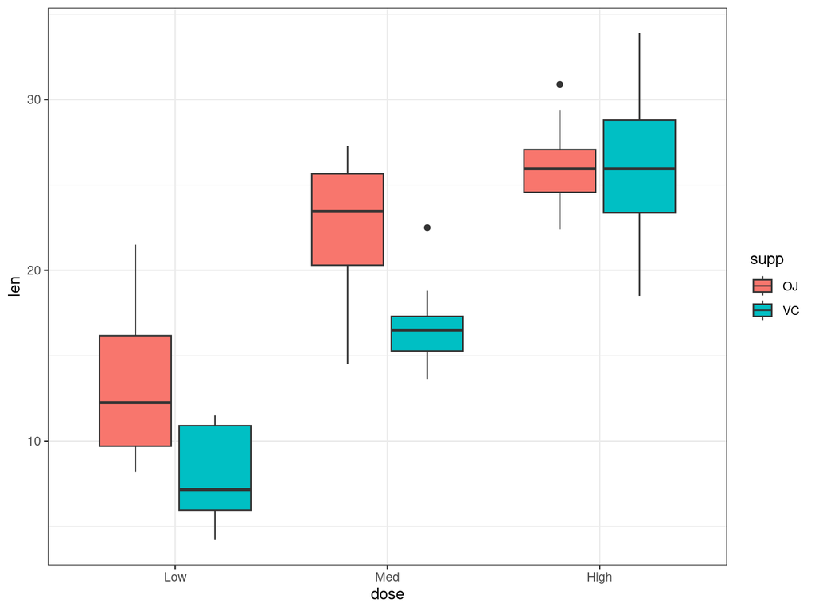

```r
theme_set(theme_bw())
pigs %>%
  ggplot(
    aes(x = dose, y = len, fill = supp)
  ) +
    geom_boxplot()
```

## t-tests

- Assumes normally distributed data
- $t$-tests always test $H_0$ Vs $H_A$

. . .

- The simplest test is on a simple vector
  - This is not particularly meaningful for our data

```r
?t.test
t.test(pigs$len)
```

**What is $H_0$ in the above test?**

## t-tests

When comparing the means of two vectors

$$H_0: \mu_{1} = \mu_{2} \\
H_A: \mu_{1} \neq \mu_{2}$$

We could use two vectors (i.e. `x` & `y`)

```r
vc <- dplyr::filter(pigs, supp == "VC")$len
oj <- dplyr::filter(pigs, supp == "OJ")$len
t.test(x = vc, y = oj)
```

. . .

**Is this a paired test?**

## t-tests

- An alternative is the `R` formula method: `len~supp`
  - Length is a response variable
  - Supplement is the predictor
- Can only use one predictor for a T-test
  - Otherwise it’s linear regression

```r
t.test(len~supp, data = pigs)
```

**Did this give the same results?**

## Wilcoxon Tests

- We assumed the above dataset was normally distributed:  
  **What if it’s not?**

. . .

- Non-parametric equivalent is the *Wilcoxon Rank-Sum* (aka *Mann-Whitney*)

. . .

- This assigns ranks to each value based on their value
  - Tied values can be problematic
- Values not used in calculation of the test statistic

```r
wilcox.test(len~supp, data = pigs)
```

## $\chi^2$ Test

- Here we need counts
- Commonly used in *Observed Vs Expected*

$$H_0: \text{No association between groups and outcome}\\
H_A: \text{Association between groups and outcome}$$

## $\chi^2$ Test

```r
pass <- matrix(c(25, 8, 6, 15), nrow = 2)
colnames(pass) <- c("Pass", "Fail")
rownames(pass) <- c("Attended", "Skipped")
pass
chisq.test(pass)
```

. . .

**Can anyone remember when we shouldn’t use a $\chi^2$ test?**

## Fisher’s Exact Test

- $\chi^2$ tests became popular in the days of the printed tables
  - We now have computers
- Fisher’s Exact Test is preferable in the cases of low cell counts
  - (Or any other time…)
- Same $H_0$ as the $\chi^2$ test
- Uses the hypergeometric distribution

```r
fisher.test(pass)
```

## Summary of Tests

- `t.test()`, `wilcox.test()`
- `chisq.test()`, `fisher.test()`

. . .

- `shapiro.test()`, `bartlett.test()`
  - Tests for normality or homogeneity of variance

. . .

- `binomial.test()`, `poisson.test()`
- `kruskal.test()`, `ks.test()`

## `htest` Objects

- All produce objects of class `htest`
- Use `print.htest()` to display results
- Is really a list
  - Use `names()` to see what other values are returned

. . .

- Can usually extract p-values using `test$p.value`

```r
fisher.test(pass)$p.value
```

# Regression

## Linear Regression

We are trying to estimate a line with slope & intercept

$$y = ax + b$$

. . .

Or

$$y = \beta_0 + \beta_1 x$$

## Linear Regression

Linear Regression always uses the `R` formula syntax

- `y ~ x`: `y` is a function of `x`
- We use the function `lm()`

```r
lm_pigs <- lm(len ~ supp , data = pigs)
summary(lm_pigs)
```

. . .

- Intercept is assumed unless explicitly removed (`~ 0 + ...`)

## Linear Regression

- It looks like `supp == VC` reduces the length of the teeth
- In reality we’d like to see if dose has an effect as well

```r
lm_pigs_dose <- lm(len ~ supp + dose, data = pigs)
summary(lm_pigs_dose)
```

. . .

- Which values are associated with the intercept & slope?

. . .

- It looks like an increasing dose-level increases length

## Interaction Terms

- We have given each group a separate intercept
  - The same slope
  - Requires an **interaction term** for different slopes

```r
lm_pigs_full <- lm(len ~ supp + dose + supp:dose, data = pigs)
summary(lm_pigs_full)
```

- How do we interpret this?

## Interaction Terms

An alternative way to write the above in `R` is:

```r
lm_pigs_full <- lm(len ~ (supp + dose)^2, data = pigs)
summary(lm_pigs_full)
```

## Model Selection

Which model should we choose?

```r
anova(lm_pigs, lm_pigs_dose, lm_pigs_full)
```

## Model Selection

Are we happy with our model assumptions?

1. Normally distributed
2. Constant Variance
3. Linear relationship

```r
plot(lm_pigs_full)
```

## Model Selection

- This creates plots using base graphics
- To show them all on the same panel

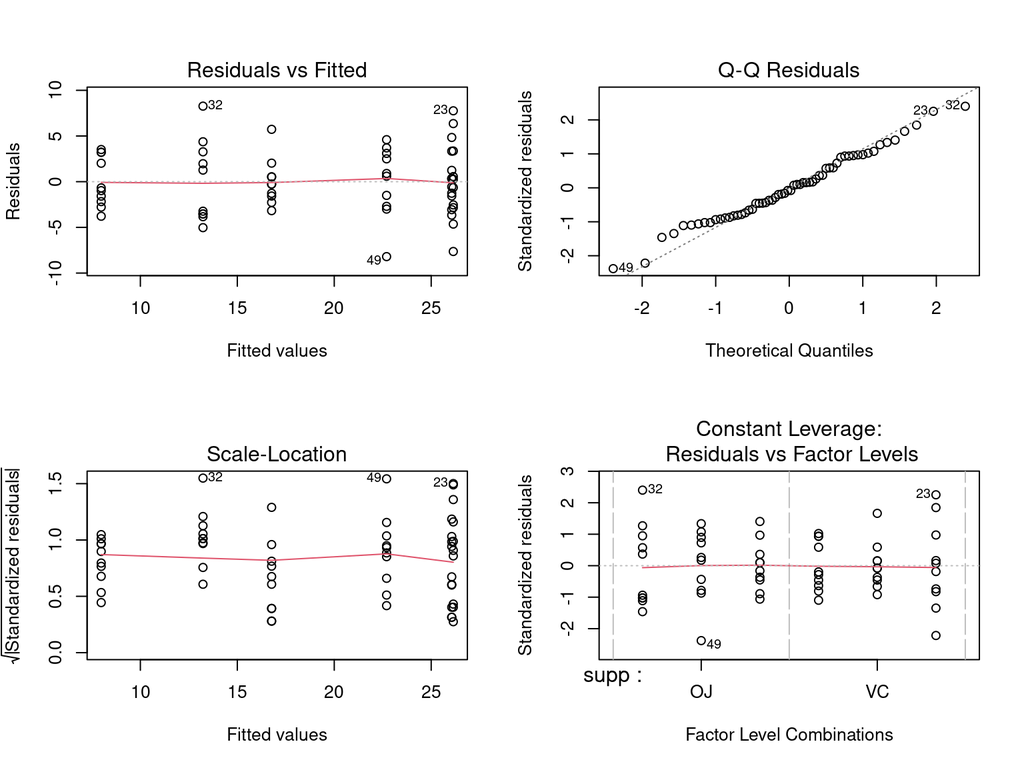

```r
par(mfrow = c(2, 2))
plot(lm_pigs_full)
```

## Visualising Residuals

- `mfrow()` stands for *multi-frame row*
- Needs to be reset to a single frame

```r
par(mfrow = c(1, 1))
```

## Logistic Regression

- Logistic Regression models probabilities (e.g. $H_0: \pi = 0$)
- We can specify two columns to the model
  - One would represent total successes, the other failures
  - This is `binomial` data, $\pi$ is the probability of success

. . .

- Alternatively the response might be a vector of `TRUE/FALSE` or `0/1`

## Logistic Regression

- The probability of admission to a PhD[^1]
  - Graduate Record Exam scores
  - Grade Point Average
  - Prestige of admitting institution (1 is most prestigous)

```r
admissions <- read_csv("https://stats.idre.ucla.edu/stat/data/binary.csv")
glimpse(admissions)
```

```
Rows: 400
Columns: 4
$ admit <dbl> 0, 1, 1, 1, 0, 1, 1, 0, 1, 0, 0, 0, 1, 0, 1, 0, 0, 0, 0, 1, 0, 1…
$ gre   <dbl> 380, 660, 800, 640, 520, 760, 560, 400, 540, 700, 800, 440, 760,…
$ gpa   <dbl> 3.61, 3.67, 4.00, 3.19, 2.93, 3.00, 2.98, 3.08, 3.39, 3.92, 4.00…
$ rank  <dbl> 3, 3, 1, 4, 4, 2, 1, 2, 3, 2, 4, 1, 1, 2, 1, 3, 4, 3, 2, 1, 3, 2…
```

## Logistic Regression

```r
glm(admit ~ gre + gpa + rank, data = admissions, family = "binomial") %>%
  summary()
```

```
Call:
glm(formula = admit ~ gre + gpa + rank, family = "binomial",
    data = admissions)

Coefficients:
             Estimate Std. Error z value Pr(>|z|)
(Intercept) -3.449548   1.132846  -3.045  0.00233 **
gre          0.002294   0.001092   2.101  0.03564 *
gpa          0.777014   0.327484   2.373  0.01766 *
rank        -0.560031   0.127137  -4.405 1.06e-05 ***
---
Signif. codes:  0 '***' 0.001 '**' 0.01 '*' 0.05 '.' 0.1 ' ' 1

(Dispersion parameter for binomial family taken to be 1)

    Null deviance: 499.98  on 399  degrees of freedom
Residual deviance: 459.44  on 396  degrees of freedom
AIC: 467.44

Number of Fisher Scoring iterations: 4
```

## Logistic Regression

- Probabilities are fit on the *logit* scale
- Transforms 0 < $\pi$ < 1 to $-\infty$ < logit($\pi$) < $\infty$

$$\text{logit}(\pi) = \log(\frac{\pi}{1-\pi})$$

## Automated Model Selection

- One strategy during model fitting is to fit a heavily parameterised model
- `R` can remove terms as required using Akaike’s Information Criterion (AIC)
  - The function is `step()`

. . .

```r
glm(admit ~ (gre + gpa + rank)^2, data = admissions, family = "binomial") %>%
  step() %>%
  summary()
```

. . .

## Mixed Effects Models

Mixed effects models include:

1. Fixed effects & 2) Random effects

May need to nest results within a biological sample, include day effects etc.

```r
Rabbit <- MASS::Rabbit
head(Rabbit)
```

## Mixed Effects Models

Here we have the change in Blood pressure within the same 5 rabbits

- 6 dose levels of control + 6 dose levels of `MDL`
- Just looking within one rabbit

```r
filter(Rabbit, Animal == "R1")
```

## Mixed Effects Models

If fitting within one rabbit $\implies$ use `lm()`

```r
lm_r1 <- lm(
  BPchange~(Treatment + Dose)^2, data = Rabbit, subset = Animal == "R1"
)
summary(lm_r1)
```

## Mixed Effects Models

To nest within each rabbit we:

- Use `lmer()` from `lme4`
- Introduce a random effect `(1|Animal)`
  - Captures variance between rabbits

```r
library(lme4)
lme_rabbit <- lmer(BPchange~Treatment + Dose + (1|Animal), data = Rabbit)
summary(lme_rabbit)
coef(summary(lme_rabbit))
```

- Mixed-effects models were originally fitted using `nlme`
- No longer being developed

## Mixed Effects Models

**Why?**

. . .

```r
library(lmerTest)
lme_rabbit <- lmer(BPchange~Treatment + Dose + (1|Animal), data = Rabbit)
summary(lme_rabbit)
```

## Mixed Effects Models

- Doug Bates & Ben Bolker are key R experts in this field
  - Doug has left the R community
- Lots of discussion for issues estimating DF with random effects
- Ben Bolker also maintains `glmmTMB` and `glmmADMB`
  - Generalised Mixed-effects Models
  - https://bbolker.github.io/mixedmodels-misc/glmmFAQ.html

Two linear algebra equations in & I was lost

## Modelling Summary

- `lm()` for standard regression models
- `glm()` for generalised linear models
- `lmer()` for linear mixed-effects models

. . .

- Robust models are implemented in `MASS`

# Other Statistical Tools

## Mutiple Testing in R

- The function `p.adjust()` takes the argument `method = ...`

```r
p.adjust.methods
```

```
[1] "holm"       "hochberg"   "hommel"     "bonferroni" "BH"
[6] "BY"         "fdr"        "none"
```

. . .

```r
lm_pigs_full %>%
  broom::tidy() %>%
  mutate(
    adjP = p.adjust(p.value, "bonf"),
    sig = case_when(
      adjP < 0.001 ~ "***",
      adjP < 0.01 ~ "**",
      adjP < 0.05 ~ "*",
      adjP < 0.1 ~ ".",
      TRUE ~ ""
    )
  )
```

. . .

Also the package `multcomp` is excellent but challenging

## PCA

- Here we have 50 genes, from two T cell types: Both Stimulated & Resting [^2]

```r
genes <- read_csv("data/geneExpression.csv")
```

. . .

- PCA requires a numeric matrix

```r
gene_mat <- genes %>%
  as.data.frame() %>%
  column_to_rownames("ID") %>%
  as.matrix()
```

## PCA

- Our variable of interest here is the cell-types
- We need to set that as the row variable:
  - Transpose the data using `t()`
  - Default settings need tweaking (`S` reverse compatability)

```r
pca <- gene_mat %>%
  t() %>%
  prcomp(center = TRUE, scale. = TRUE)
summary(pca)
biplot(pca)
```

```r
screeplot(pca)
```

. . .

## PCA

- The output of `prcomp()` is a list with class `prcomp`
- Components are in `pca$x`
- Gene loadings are in `pca$rotation`
  - Contributions of each gene to each component

. . .

```r
pca %>% broom::tidy()
```

## PCA

- My go-to visualisation trick is

```r
pca %>%
  broom::tidy() %>%
  pivot_wider(names_from = "PC", values_from = "value", names_prefix = "PC") %>%
  ggplot(aes(PC1, PC2)) +
  geom_point()
```

## PCA Challenge

In this dataset:

- Treg & Th cells
- Resting encoded with `-`
- Stimulated encoded with `+`
- Final number is the donor

. . .

1. *Colour the points by cell type and set the shape by treatment*
2. *Add labels to each point*  
   (Hint: Use `ggrepel::geom_label_repel()`)

## Footnotes

[^1]: Taken from https://stats.oarc.ucla.edu
[^2]: Courtesy of Prof Simon Barry